# Assignment 3 CBA, Green Hydrogen

Kristin Art, Hannah Irish, Lillian Liu, Nadine Snyder

2023-11-19

Read in historical emissions data for industrial and transportation emissions:

```r
## read in historical data on emissions from CARB
ghg_historical_ca <- read_csv(here::here("data/arb_ghg_2000-2020.csv")) %>%
  janitor::clean_names()

## separate transportation
trans_hist_ghg_ca <- ghg_historical_ca %>%
  filter(sector == "Transportation")

## separate industrial
ind_hist_ghg_ca <- ghg_historical_ca %>%
  filter(sector == "Industrial")
```

Use linear regression to find the trend of emissions, no intervention

```r
## linear model for transportation
trans_emissions_lm <- lm(mmt_co23 ~ year, data = trans_hist_ghg_ca)

## extract slope
trans_coef <- coef(trans_emissions_lm)
trans_int <- trans_coef[1]
trans_slope <- trans_coef[2]

## linear model for industrial
ind_emissions_lm <- lm(mmt_co23 ~ year, data = ind_hist_ghg_ca)

## extract slope
ind_coef <- coef(ind_emissions_lm)
ind_int <- ind_coef[1]
ind_slope <- ind_coef[2]

## define lm functions
calculate_ind_co2e <- function(year) {
  co2e <- (ind_slope * year + ind_int) * 1000
}

calculate_trans_co2e <- function(year) {
  co2e <- (trans_slope * year + trans_int) * 1000
}
```

Develop counterfactual emissions

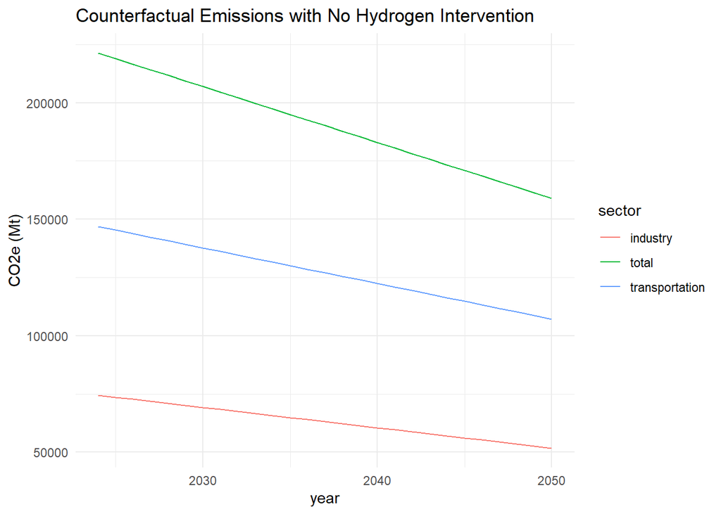

```r
## make vector of years
year <- seq(2021, 2050)

## turn into df and add columns for transportation and industrial emissions
counterfactual <- year %>%
  as.data.frame() %>%
  rename("year" = 1) %>%
  mutate(
    transportation = calculate_trans_co2e(year),
    industry = calculate_ind_co2e(year),
    total= transportation+industry
  ) %>%
  filter(year >= 2024)

## pivot longer
counterfactual_longer <- counterfactual %>%
  filter(year <= "2050") %>%
  mutate(total_emissions = industry + transportation) %>%
  pivot_longer(cols = c(2, 3, 4), names_to = "sector", values_to = "mt_co2e")

## plot to check
ggplot() +
  geom_line(data = counterfactual_longer, aes(x = year, y = mt_co2e, col = sector)) +
  labs(x = "year", y = "CO2e (Mt)", title = "Counterfactual Emissions with No Hydrogen Intervention") +
  theme_minimal()
```

Read in Base Case Buildout Information

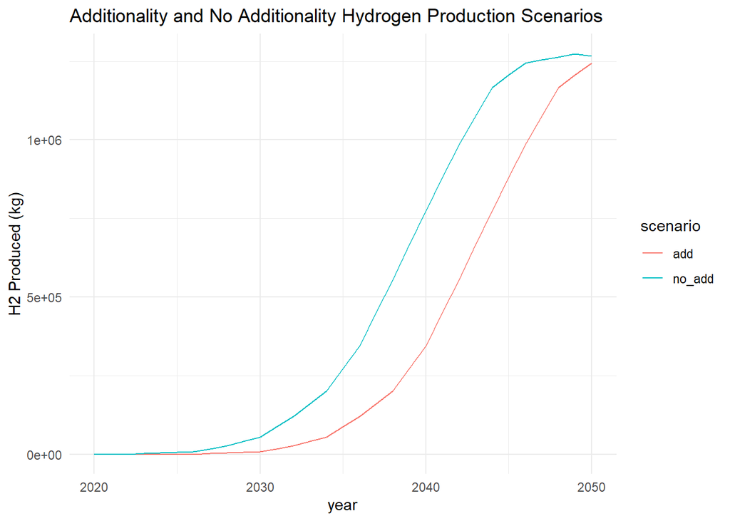

```r
## read in Reed paper buildout by year (estimated from graph)
h2_buildout <- read_csv(here::here("data/H2_from_electrolysis.csv")) %>%
  select(1, 4)
colnames(h2_buildout) <- c("year", "no_add")

## lag by 4 years for additionality scenario
h2_scenarios <- h2_buildout %>%
  mutate(add = lag(no_add, 4)) # is this a 2-year lag?

## add 0 to first two rows of additionality
h2_scenarios$add[1:4] <- 0
# h2_scenarios$add[2] = 0

h2_scenarios_tidy <- h2_scenarios %>%
  pivot_longer(cols = c(2, 3), names_to = "scenario", values_to = "mt_h2")

ggplot() +
  geom_line(data = h2_scenarios_tidy, aes(x = year, y = mt_h2, col = scenario)) +
  labs(x = "year", y = "H2 Produced (kg)", title = "Additionality and No Additionality Hydrogen Production Scenarios") +
  theme_minimal()
```

Read in industry and transportation (non-LDV) percentage values

```r
## read in data with the percentage of hydrogen demand attributable to non-LDVs and industry
percent_demand <- read_csv(here::here("data/non-LDV_vs_Industry_Demand.csv")) %>%
  select(c(1, 8, 9))

## add percent data
percents_df <- merge(percent_demand, h2_scenarios)

## calculate h2 production that will go to each demand type
final_h2 <- percents_df %>%
  mutate(
    "no_additionality_trans" = transportation_pct * no_add,
    "no_additionality_ind" = industry_pct * no_add,
    "additionality_trans" = transportation_pct * add,
    "additionality_industry" = industry_pct * add
  ) %>%
  select(c(1, 6, 7, 8, 9))

## choose additionality situations
additionality <- final_h2 %>%
  select(1, 4, 5)
colnames(additionality) <- c("year", "transportation", "industry")

## choose non-additionality situations
no_additionality <- final_h2 %>%
  select(1, 2, 3)

colnames(no_additionality) <- c("year", "transportation", "industry")
```

Find amount of CO2 emissions reduction saved by final H2 scenarios and sectors

```r
## for transportation:
## 1 kg h2 = 0.9gal diesel. 1 metric ton  1000kg. 1 gal diesel = 10.18*10^-3 CO2 tons so
# h2mt * 1000kg/mt * 0.9gal diesel/1kg h2 *10*10^-3 co2 kg/1gal diesel * 1ton/1000kg co2

## for industry:
## 1 kg h2 = 0.000117 mcf natural gas *0.0551 ton CO2/1mcf natural gas
# h2mt * 1000kg/mt * 0.000117 mcf nat gas/kgh2 * 0.0551 co2 tons/mcf natural gas

## calculate co2 saved (emission reductions) from fuel displacement by hydrogen for additionality scenario
additionality_co2 <- additionality %>%
  mutate("transportation" = transportation * 1000 * 0.9 * 10.180 * 0.001 / 1000) %>%
  mutate("industry" = industry * 1000 * 0.000117 * 0.0551) %>%
  mutate("total" = industry+transportation)

## calculate co2 saved (emission reductions) from fuel displacement by hydrogen for non-additionality scenario
no_additionality_co2 <- no_additionality %>%
  mutate("transportation" = transportation * 1000 * 0.9 * 10.180 * 0.001 / 1000) %>%
  mutate("industry" = industry * 1000 * 0.000117 * 0.0551) %>%
  mutate("total" = industry+transportation)
```

Calculate NPV of emissions reductions for each scenario using benefits transfer

We used the social cost of carbon (SCC) from RFF, which was calculated as:
$$SCC = \sum_{n=1}^{t}
\frac{damage}{1 + r^t} = \frac{185 USD}{1 ton C}$$
where:

- time, t = 400 years
- discount rate, r = 2%

When we rearrange their equation to solve for damage, we found that damage = $3.77 in 2020 USD.

We also assume a discount rate, r, of 5%, which is the average discount rate based on the literature.

```r
## define scc
damages <- 4.40

## define discount rate
rho <- 0.05 ## using dsct value of 5%

present_value = vector(mode="numeric", length=0)
for(i in 1:27){
  present_value[i] = damages/(1+rho)^i
}

scc_original = sum(present_value)



# calculate the pv of the co2 reductions under each scenario
no_add_scc <- no_additionality_co2 %>%
  filter(year >= "2024")%>%
  mutate(
    total_reduction = total,
    t = seq(1, 27),
    pv = (total_reduction*scc_original) /((1 + rho)^t)
  )

add_scc <- additionality_co2 %>%
   mutate("industry" = industry, "transportation" = transportation) %>%
 filter(year >= "2024")%>%
  mutate(
    total_reduction = total,
    t = seq(1, 27),
    pv = (total_reduction*scc_original) /((1 + rho)^t)
  )

# sum the pvs to get npv
npv_additionality <- sum(add_scc$pv)
npv_no_additionality <- sum(no_add_scc$pv)
```

The total net present value of the $CO_2$ emissions reductions under the additionality intervention scenario is $725,135.9

The total net present value of the $CO_2$ emissions reductions under the no additionality intervention scenario is $1,152,587

The **no additionality** scenario has the larger net present value based on the $CO_2$ emissions reductions indicator, which was valuated using a benefit transfer.

Partial sensitivity analysis of NPV’s sensitivity to discount rate, r

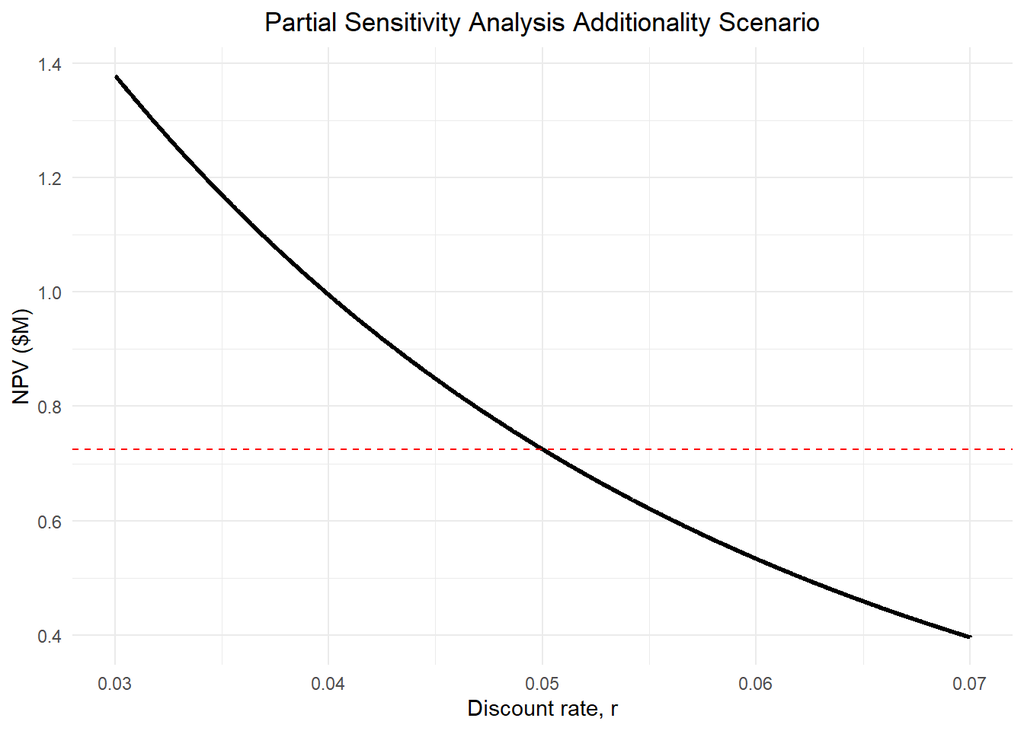

```r
# Partial sensitivity analysis where we hold all variables constant except for one, r
# define vector of r values
r <- runif(min = 0.03, max = 0.07, n = 5000)

# define constant inputs

damages_2023 <- 4.40 ##3.7 damages in 2020 per RFF means 4.4 in 2023


scc_gen <- function(discount_rate){
  present_value = vector(mode="numeric", length =0)

  for (i in 1:27){
    present_value[i] = damages_2023/(1+discount_rate)^i
  }

  npv=sum(present_value)
  return(npv)
}

r_df <- data.frame(dsct = r)

r_scc_df <- r_df %>%
  mutate(scc_2023 = map_dbl(dsct, scc_gen))

#avg_total_emissions_reductions<- mean(c(sum(add_scc$total), sum(no_add_scc$total)))

t <- seq(1, 27, 1)

# define df with empty column for pv
df <- t %>%
  as.data.frame() %>%
  rename("t" = 1) %>%
  mutate(pv = NA)


additionality_co2_vec <- add_scc$total_reduction

calculate_npv_additionality <- function(scc, r) {
  # calculate pv of emisison reductions
  value = vector(mode="numeric", length=0)
  for(i in 1:27){
    value[i] = (additionality_co2_vec[i]*scc)/(1+r)^i
  }
  return(sum(value))
}


no_additionality_co2_vec <- no_add_scc$total_reduction

calculate_npv_no_additionality <- function(scc, r) {
  # calculate pv of emisison reductions
  value = vector(mode="numeric", length=0)
  for(i in 1:27){
    value[i] = (no_additionality_co2_vec[i]*scc)/(1+r)^i
  }
  return(sum(value))
}



r_scc_df_add <- r_scc_df %>%
  mutate(npv = map2_dbl(scc_2023, dsct, calculate_npv_additionality))

r_scc_df_no_add <- r_scc_df %>%
  mutate(npv = map2_dbl(scc_2023, dsct, calculate_npv_no_additionality))



scc_2023 = scc_gen(0.05)

#calculate NPV from our chosen r value (5%) for comparison plot
npv_chosenr_add <- calculate_npv_additionality(r = 0.05, scc = scc_2023)

npv_chosenr_no_add <- calculate_npv_no_additionality(r = 0.05, scc = scc_2023)

# plot results additionality
ggplot() +
  geom_line(data = r_scc_df_add/1000000, aes(x = r, y = npv), size = 1) +
  geom_hline(yintercept = npv_chosenr_add/1000000, linetype = "dashed", color = "red") +
  labs(x = "Discount rate, r", y = "NPV ($M)", title = "Partial Sensitivity Analysis Additionality Scenario") +
  theme_minimal() +
  theme(plot.title = element_text(hjust = 0.5),
        legend.position = "right")
```

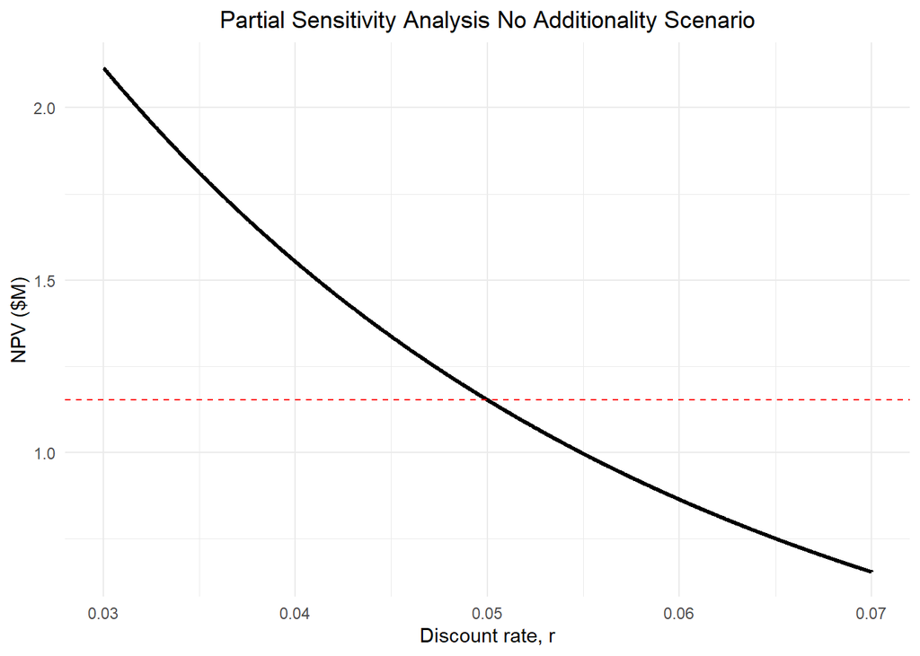

```r
# plot results no additionality
ggplot() +
  geom_line(data = r_scc_df_no_add/1000000, aes(x = r, y = npv), size = 1) +
  geom_hline(yintercept = npv_chosenr_no_add/1000000, linetype = "dashed", color = "red") +
  labs(x = "Discount rate, r", y = "NPV ($M)", title = "Partial Sensitivity Analysis No Additionality Scenario") +
  theme_minimal() +
  theme(plot.title = element_text(hjust = 0.5),
        legend.position = "right") + scale_x_continuous()
```